# Ch2. 엑셀의 VLOOKUP 및 여러기능 판다스로 해보기

```python
import warnings
warnings.filterwarnings(action = 'ignore')

from IPython.display import Image
```

## 1. 엑셀 파일에서 데이터프레임 불러오기(read_excel)

> pandas read_excel

엑셀파일을 데이터프레임으로 불러오는 함수

**io**

파일의 경로명

**sheet_name** (인수는 문자열, 정수, 리스트 / 기본값은 0)

불러올 시트를 지정하는 인자

예)

- 지정하지 않을 때: 첫번째 시트를 불러온다
- 1: 2번째 시트를 불러온다
- "Sheet1": 문자열을 입력하면 해당 이름을 가진 시트를 불러온다. 여기서는 "Sheet1"이라는 이름의 시트를 불러온다
- [0, 1, "Sheet5"]: 첫번째 시트와 두번째 시트 그리고 "Sheet5"라는 이름의 시트 세개를 딕셔너리로 통합해 가져온다.
- None: 모든 시트를 딕셔너리로 통합해 가져온다.

**header** (인수는 정수, 정수의 리스트 / 기본값은 0)

columns를 지정하는 인자. 지정하지 않으면 맨 윗줄이 columns가 된다.

리스트로 지정하면 멀티 인덱스인 columns가 된다.

**index_col** (인수는 정수, 정수의 리스트 / 기본값은 None)

index를 지정하는 인자. 지정하지 않으면 RangeIndex가 index로 부여된다.

리스트로 지정하면 멀티 인덱스인 index가 된다.

[read_excel 함수 설명 블로그](https://kimpanda.tistory.com/68)

[read_excel 판다스 공식 문서](https://pandas.pydata.org/docs/reference/api/pandas.read_excel.html)

```python
import pandas as pd
```

```python
# 먼저 파일을 업로드 후 경로를 복사해서 변수(여기서는 url)로 지정한다
url = '02_01_read_excel.xlsx'

# read_excel 함수로 데이터프레임을 불러온다. 기본값으로는 첫번째 시트
df = pd.read_excel(url)
df
```

|  | 이름 | 국어 | 영어 | 수학 |
| --- | --- | --- | --- | --- |
| 0 | 송중기 | 63 | 93 | 97 |
| 1 | 김나현 | 89 | 83 | 71 |
| 2 | 권보아 | 83 | 76 | 92 |
| 3 | 박효신 | 94 | 88 | 73 |

```python
# 두번째 시트 불러오기
pd.read_excel(url, sheet_name=1)
```

|  | 두 | 번 | 째 | 시트 |
| --- | --- | --- | --- | --- |
| 0 | 송중기 | 63 | 93 | 97 |
| 1 | 김나현 | 89 | 83 | 71 |
| 2 | 권보아 | 83 | 76 | 92 |
| 3 | 박효신 | 94 | 88 | 73 |

```python
# 세번째 시트를 불러오되 세번째 행을 columns로 지정하기
pd.read_excel(url, sheet_name=2, header=2)
```

|  | 이름 | 국어 | 영어 | 수학 |
| --- | --- | --- | --- | --- |
| 0 | 송중기 | 63 | 93 | 97 |
| 1 | 김나현 | 89 | 83 | 71 |
| 2 | 권보아 | 83 | 76 | 92 |
| 3 | 박효신 | 94 | 88 | 73 |

```python
# 네번째 시트를 불러오되 첫번째 열을 index로 지정하기
pd.read_excel(url, sheet_name=3, index_col=0)
```

|  | 국어 | 영어 | 수학 |
| --- | --- | --- | --- |
| 송중기 | 63 | 93 | 97 |
| 김나현 | 89 | 83 | 71 |
| 권보아 | 83 | 76 | 92 |
| 박효신 | 94 | 88 | 73 |

## 2. 단일요건 vlookup (merge)

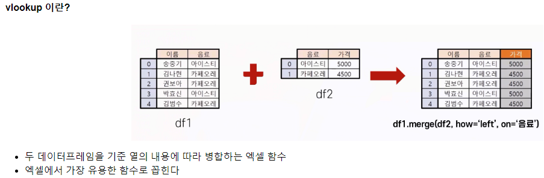

```python
Image('1.png')
```

> padas merge

**right** (인수 데이터프레임 혹은 시리즈)

병합할 객체

**how** (인수는 ‘left’, ‘right’, ‘outer’, ‘inner’, ‘cross’ / 기본값은 ‘inner’)

병합할 방식을 결정하는 인자.

- left: 왼쪽 데이터프레임의 키(key)만을 병합에 사용한다.(엑셀의 vlookup과 유사)
- right: 오른쪽 데이터프레임의 키(key)만을 병합에 사용한다.
- outer: 양쪽 데이터프레임의 키(key)들의 합집합을 병합에 사용한다.
- inner: 양쪽 데이터프레임의 키(key)들의 교집합을 병합에 사용한다.
- cross: 양쪽 데이터프레임의 곱집합(cartesian product)을 생성한다.

**on** (인수는 열의 레이블 또는 리스트 / 기본값은 None)

병합의 기준이 되는 열을 지정하는 인자.

기본 값은 양쪽 데이터프레임에서 이름이 공통인 열들이 지정된다.

리스트로 입력하면 복수의 열을 기준으로 병합한다.

[merge 함수 설명 블로그](https://kimpanda.tistory.com/69)

[merge 판다스 공식 문서](https://pandas.pydata.org/docs/reference/api/pandas.DataFrame.merge.html)

```python
import pandas as pd
```

```python
# 판다스 출력옵션 조절
#pd.set_option('max_rows', 6)
```

```python
url = '02_02_merge01.xlsx'
df1 = pd.read_excel(url)
df1
```

|  | 이름 | 제품 |
| --- | --- | --- |
| 0 | 백철민 | 아이스티 |
| 1 | 박태인 | 레몬에이드 |
| 2 | 국지용 | 아메리카노 |
| 3 | 강민석 | 레몬에이드 |
| 4 | 박훈정 | 아이스티 |
| ... | ... | ... |
| 369 | 김경남 | 아메리카노 |
| 370 | 기정수 | 유자차 |
| 371 | 기주봉 | 아이스티 |
| 372 | 백승환 | 바닐라라떼 |
| 373 | 계승현 | 레몬에이드 |

374 rows × 2 columns

```python
df2 = pd.read_excel(url, sheet_name=1)
df2
```

|  | 제품 | 가격 |
| --- | --- | --- |
| 0 | 아메리카노 | 3900 |
| 1 | 바닐라라떼 | 3900 |
| 2 | 까페라떼 | 3900 |
| 3 | 아이스티 | 4400 |
| 4 | 얼그레이 | 3800 |
| 5 | 유자차 | 3500 |
| 6 | 아인슈페너 | 3500 |
| 7 | 자몽티 | 4100 |
| 8 | 레몬에이드 | 4400 |
| 9 | 오렌지주스 | 3600 |

```python
# df1과 df2를 vlookup 방식으로 병합
df3 = df1.merge(df2, how='left', on='제품')
df3
```

|  | 이름 | 제품 | 가격 |
| --- | --- | --- | --- |
| 0 | 백철민 | 아이스티 | 4400 |
| 1 | 박태인 | 레몬에이드 | 4400 |
| 2 | 국지용 | 아메리카노 | 3900 |
| 3 | 강민석 | 레몬에이드 | 4400 |
| 4 | 박훈정 | 아이스티 | 4400 |
| ... | ... | ... | ... |
| 369 | 김경남 | 아메리카노 | 3900 |
| 370 | 기정수 | 유자차 | 3500 |
| 371 | 기주봉 | 아이스티 | 4400 |
| 372 | 백승환 | 바닐라라떼 | 3900 |
| 373 | 계승현 | 레몬에이드 | 4400 |

374 rows × 3 columns

```python
# 결과를 엑셀 파일로 저장하기
df3.to_excel('result_merge01.xlsx')
```

## 3. 다중요건 vlookup (merge)

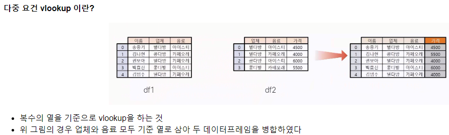

```python
Image('2.png')
```

```python
import pandas as pd
#pd.set_option('max_rows', 6)
data1 = [['송중기', '별다방', '아이스티'],
         ['김나현', '콩다방', '카페오레'],
         ['권보아', '별다방', '카페오레'],
         ['박효신', '콩다방', '아이스티'],
         ['김범수', '별다방', '카페오레']]
data2 = [['별다방', '아이스티', 4500],
         ['별다방', '카페오레', 4000],
         ['콩다방', '아이스티', 6000],
         ['콩다방', '카페오레', 5500]]
df1 = pd.DataFrame(data1, columns=['이름', '업체', '음료'])
df2 = pd.DataFrame(data2, columns=['업체', '음료', '가격'])
```

```python
df1
```

|  | 이름 | 업체 | 음료 |
| --- | --- | --- | --- |
| 0 | 송중기 | 별다방 | 아이스티 |
| 1 | 김나현 | 콩다방 | 카페오레 |
| 2 | 권보아 | 별다방 | 카페오레 |
| 3 | 박효신 | 콩다방 | 아이스티 |
| 4 | 김범수 | 별다방 | 카페오레 |

```python
df2
```

|  | 업체 | 음료 | 가격 |
| --- | --- | --- | --- |
| 0 | 별다방 | 아이스티 | 4500 |
| 1 | 별다방 | 카페오레 | 4000 |
| 2 | 콩다방 | 아이스티 | 6000 |
| 3 | 콩다방 | 카페오레 | 5500 |

```python
# df1과 df2를 업체와 음료 두개의 열로 vlookup 하기
df1.merge(df2, how='left', on=['업체', '음료'])
```

|  | 이름 | 업체 | 음료 | 가격 |
| --- | --- | --- | --- | --- |
| 0 | 송중기 | 별다방 | 아이스티 | 4500 |
| 1 | 김나현 | 콩다방 | 카페오레 | 5500 |
| 2 | 권보아 | 별다방 | 카페오레 | 4000 |
| 3 | 박효신 | 콩다방 | 아이스티 | 6000 |
| 4 | 김범수 | 별다방 | 카페오레 | 4000 |

```python
# 기본 값으로 양쪽 데이터프레임에서 공통인 열이 모두 on으로 지정된다
df1.merge(df2, how='left')
```

|  | 이름 | 업체 | 음료 | 가격 |
| --- | --- | --- | --- | --- |
| 0 | 송중기 | 별다방 | 아이스티 | 4500 |
| 1 | 김나현 | 콩다방 | 카페오레 | 5500 |
| 2 | 권보아 | 별다방 | 카페오레 | 4000 |
| 3 | 박효신 | 콩다방 | 아이스티 | 6000 |
| 4 | 김범수 | 별다방 | 카페오레 | 4000 |

```python
# 엑셀파일로 한번 더 실습해보자
url = '02_03_merge02.xlsx'
df3 = pd.read_excel(url)
df4 = pd.read_excel(url, sheet_name=1)
```

```python
df3
```

|  | 이름 | 제품 | 업체 |
| --- | --- | --- | --- |
| 0 | 백민 | 산채비빔밥 | 종가도시락 |
| 1 | 권상우 | 치킨도시락 | 두솥도시락 |
| 2 | 강인서 | 돈까스정식 | 두솥도시락 |
| 3 | 백종민 | 산채비빔밥 | 두솥도시락 |
| 4 | 권혁범 | 산채비빔밥 | 두솥도시락 |
| ... | ... | ... | ... |
| 369 | 박민규 | 산채비빔밥 | 두솥도시락 |
| 370 | 문영동 | 돈까스정식 | 두솥도시락 |
| 371 | 백철민 | 돈까스정식 | 두솥도시락 |
| 372 | 김두진 | 산채비빔밥 | 종가도시락 |
| 373 | 김동수 | 돈까스정식 | 두솥도시락 |

374 rows × 3 columns

```python
df4
```

|  | 업체 | 제품 | 가격 | 구분 |
| --- | --- | --- | --- | --- |
| 0 | 두솥도시락 | 돈까스정식 | 5700 | 일식 |
| 1 | 두솥도시락 | 산채비빔밥 | 5200 | 한식 |
| 2 | 두솥도시락 | 치킨도시락 | 6300 | 한식 |
| 3 | 종가도시락 | 돈까스정식 | 6600 | 일식 |
| 4 | 종가도시락 | 산채비빔밥 | 6700 | 한식 |
| 5 | 종가도시락 | 치킨도시락 | 5600 | 한식 |

```python
# df3와 df4를 다중요건 vlookup을 한 뒤 엑셀파일로 저장하자
df3.merge(df4, how='left').to_excel('result_merge02.xlsx', index=False)
```

[figure not shown]

```python
Image('3.png')
```

merge 함수에 대해서 더 공부가 필요한 분들은 아래 강의를 참고하세요

- [엑셀투파이썬 채널 merge 강의](https://youtu.be/7bc04EbPtcE)

## 4. 행과 열의 이름 바꾸기(rename)

> pandas rename

**index** (인수는 mapper)

index의 이름을 바꾸는 인자

- mapper란? 딕셔너리나 시리즈나 함수와 같이 맵핑을 할수 있는 매개체

**columns** (인수는 mapper)

columns의 이름을 바꾸는 인자

**level** (인수는 level의 로케이션 혹은 레이블 / 기본값은 None)

멀티인덱스에서 이름을 바꿀 레벨을 지정하는 인자. 기본값은 모든 level에서 이름을 바꾼다.

[rename 함수 설명 블로그](https://kimpanda.tistory.com/72)

[rename 판다스 공식문서](https://pandas.pydata.org/docs/reference/api/pandas.DataFrame.rename.html)

```python
import pandas as pd
pd.set_option('max_rows', 6)
data1 = [['송중기', '별다방', '아이스티'],
         ['김나현', '콩다방', '카페오레'],
         ['권보아', '별다방', '카페오레'],
         ['박효신', '콩다방', '아이스티'],
         ['김범수', '별다방', '카페오레']]
data2 = [['별다방', '아이스티', 4500],
         ['별다방', '카페오레', 4000],
         ['콩다방', '아이스티', 6000],
         ['콩다방', '카페오레', 5500]]
df1 = pd.DataFrame(data1, columns=['이름', '업체', '음료'])
df2 = pd.DataFrame(data2, columns=['업체', '제품', '가격'])
```

```python
# 제품 열을 음료 열로 열의 이름을 바꿔보자
df2.rename(columns={'제품':'음료'})
```

|  | 업체 | 음료 | 가격 |
| --- | --- | --- | --- |
| 0 | 별다방 | 아이스티 | 4500 |
| 1 | 별다방 | 카페오레 | 4000 |
| 2 | 콩다방 | 아이스티 | 6000 |
| 3 | 콩다방 | 카페오레 | 5500 |

```python
# df2를 실행해보라(함수의 결과는 원본을 덮어쓰지 않는다)
df2
```

|  | 업체 | 제품 | 가격 |
| --- | --- | --- | --- |
| 0 | 별다방 | 아이스티 | 4500 |
| 1 | 별다방 | 카페오레 | 4000 |
| 2 | 콩다방 | 아이스티 | 6000 |
| 3 | 콩다방 | 카페오레 | 5500 |

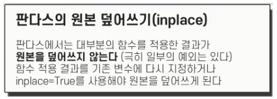

```python
Image('4.png')
```

```python
# 함수의 적용결과가 원본을 덮어쓰지 않기에 새로운 변수로 지정해야 한다
df3 = df2.rename(columns={'제품':'음료'})
df1.merge(df3, how='left')
```

|  | 이름 | 업체 | 음료 | 가격 |
| --- | --- | --- | --- | --- |
| 0 | 송중기 | 별다방 | 아이스티 | 4500 |
| 1 | 김나현 | 콩다방 | 카페오레 | 5500 |
| 2 | 권보아 | 별다방 | 카페오레 | 4000 |
| 3 | 박효신 | 콩다방 | 아이스티 | 6000 |
| 4 | 김범수 | 별다방 | 카페오레 | 4000 |

```python
# 혹은 함수를 적용 결과를 그대로 사용해도 된다
df1.merge(df2.rename(columns={'제품':'음료'}), how='left')
```

|  | 이름 | 업체 | 음료 | 가격 |
| --- | --- | --- | --- | --- |
| 0 | 송중기 | 별다방 | 아이스티 | 4500 |
| 1 | 김나현 | 콩다방 | 카페오레 | 5500 |
| 2 | 권보아 | 별다방 | 카페오레 | 4000 |
| 3 | 박효신 | 콩다방 | 아이스티 | 6000 |
| 4 | 김범수 | 별다방 | 카페오레 | 4000 |

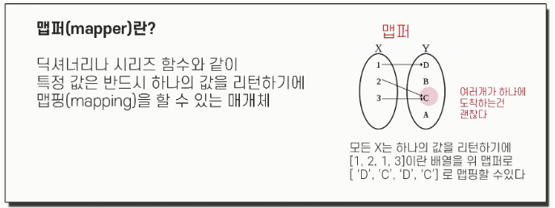

```python
Image('5.png')
```

## 5. 정렬하기 (sort_values)

> pandas sort_values

**by** (인수는 label 또는 label의 리스트)

정렬의 기준이 될 배열(주로 정렬의 기준인 열)을 지정하는 인자

**ascending** (인수는 bool 또는 bool의 리스트 / 기본값은 True)

정렬 순서를 오름차순으로 정렬할지 내림차순으로 정렬할지 지정하는 인자

[sort_values 함수 설명 블로그](https://kimpanda.tistory.com/71)

[sort_values 판다스 공식 문서](https://pandas.pydata.org/docs/reference/api/pandas.DataFrame.sort_values.html)

```python
import pandas as pd
data = [[60, 84, 80, 70, 19],
        [77, 62, 95, 85, 17],
        [61, 97, 72, 67, 15],
        [75, 65, 95, 51, 18]]
cols = ['국어', '영어', '수학', '과학', '나이']
df = pd.DataFrame(data, index=['A', 'B', 'C', 'D'], columns=cols)
df
```

|  | 국어 | 영어 | 수학 | 과학 | 나이 |
| --- | --- | --- | --- | --- | --- |
| A | 60 | 84 | 80 | 70 | 19 |
| B | 77 | 62 | 95 | 85 | 17 |
| C | 61 | 97 | 72 | 67 | 15 |
| D | 75 | 65 | 95 | 51 | 18 |

```python
# 국어열을 기준으로 오름차순으로 정렬하기
df.sort_values('국어')
```

|  | 국어 | 영어 | 수학 | 과학 | 나이 |
| --- | --- | --- | --- | --- | --- |
| A | 60 | 84 | 80 | 70 | 19 |
| C | 61 | 97 | 72 | 67 | 15 |
| D | 75 | 65 | 95 | 51 | 18 |
| B | 77 | 62 | 95 | 85 | 17 |

```python
# df는 바뀌지 않는다 (원본을 덮어쓰지 않음)
df
```

|  | 국어 | 영어 | 수학 | 과학 | 나이 |
| --- | --- | --- | --- | --- | --- |
| A | 60 | 84 | 80 | 70 | 19 |
| B | 77 | 62 | 95 | 85 | 17 |
| C | 61 | 97 | 72 | 67 | 15 |
| D | 75 | 65 | 95 | 51 | 18 |

```python
# 영어 열을 기준으로 내림차순으로 정렬하기
df.sort_values('영어', ascending=False)
```

|  | 국어 | 영어 | 수학 | 과학 | 나이 |
| --- | --- | --- | --- | --- | --- |
| C | 61 | 97 | 72 | 67 | 15 |
| A | 60 | 84 | 80 | 70 | 19 |
| D | 75 | 65 | 95 | 51 | 18 |
| B | 77 | 62 | 95 | 85 | 17 |

```python
# 수학으로 정렬하되 수학이 동점이면 과학으로 정렬 (모두 내림차순)
df.sort_values(['수학', '과학'], ascending=False)
```

|  | 국어 | 영어 | 수학 | 과학 | 나이 |
| --- | --- | --- | --- | --- | --- |
| B | 77 | 62 | 95 | 85 | 17 |
| D | 75 | 65 | 95 | 51 | 18 |
| A | 60 | 84 | 80 | 70 | 19 |
| C | 61 | 97 | 72 | 67 | 15 |

```python
# 수학으로 내림차순으로 정렬하되 수학이 동점이면 과학으로 오름차순 정렬
df.sort_values(['수학', '과학'], ascending=[0, 1])
```

|  | 국어 | 영어 | 수학 | 과학 | 나이 |
| --- | --- | --- | --- | --- | --- |
| D | 75 | 65 | 95 | 51 | 18 |
| B | 77 | 62 | 95 | 85 | 17 |
| A | 60 | 84 | 80 | 70 | 19 |
| C | 61 | 97 | 72 | 67 | 15 |

## 6. 범위로 병합하기 (merge_asof)

```python
'''
`merge_asof()` 함수는 pandas 라이브러리에서 제공되는
데이터프레임을 병합하는 함수 중 하나입니다.
이 함수는 시간 기반으로 데이터를 병합할 때 유용하게 사용됩니다.
특히, 시간 기준으로 정렬된 두 데이터프레임을 결합할 때 사용됩니다.

`merge_asof()` 함수는 왼쪽 데이터프레임과 오른쪽 데이터프레임 간의 시간 기반으로
가장 가까운 값에 따라 결합합니다.
여기서 "가장 가까운 값"은 시간 기준으로 정렬된 열을 기준으로 합니다.

이 함수의 주요 인자들은 다음과 같습니다:

 1. `left`: 왼쪽 데이터프레임입니다. 병합할 기준이 되는 데이터프레임입니다.
 2. `right`: 오른쪽 데이터프레임입니다.
         왼쪽 데이터프레임과 병합할 데이터프레임입니다.
 3. `on`: 기준이 되는 열입니다. 일반적으로 시간 열이 여기에 지정됩니다.
 4. `left_on`: 왼쪽 데이터프레임의 기준 열을 지정합니다.
         기본값은 `on`으로 지정된 열입니다.
 5. `right_on`: 오른쪽 데이터프레임의 기준 열을 지정합니다.
         기본값은 `on`으로 지정된 열입니다.
 6. `by`: 기준 열 간의 정렬 방식을 제어합니다.
         기본적으로 `on`으로 지정된 열을 기준으로 정렬됩니다.
 7. `tolerance`: 왼쪽과 오른쪽 값 사이의 최대 차이를 지정합니다.
         이 값 이내에서만 값이 가까운 것으로 간주됩니다.
 8. `allow_exact_matches`: 정확히 일치하는 값도 허용할지 여부를 결정합니다.
         기본값은 `True`입니다.
 9. `direction`: 결합 방향을 지정합니다.
         'backward', 'forward', 'nearest' 중 하나를 선택할 수 있습니다.

이렇게 하여 `merge_asof()` 함수는 두 데이터프레임 간에 시간 기준으로
가장 가까운 값에 따라 결합할 수 있도록 해줍니다.
'''

import pandas as pd

# 주가 데이터프레임
price_df = pd.DataFrame({
    'time': pd.to_datetime(['2024-04-01 09:00', '2024-04-01 09:30',
                            '2024-04-01 10:00', '2024-04-01 10:30']),
    'price': [100, 105, 110, 115]
})

price_df
```

|  | time | price |
| --- | --- | --- |
| 0 | 2024-04-01 09:00:00 | 100 |
| 1 | 2024-04-01 09:30:00 | 105 |
| 2 | 2024-04-01 10:00:00 | 110 |
| 3 | 2024-04-01 10:30:00 | 115 |

```python
# 이벤트 데이터프레임
event_df = pd.DataFrame({
    'event_time': pd.to_datetime(['2024-04-01 09:20', '2024-04-01 10:05']),
    'event': ['Earnings Release', 'Economic Data Release']
})

event_df
```

|  | event_time | event |
| --- | --- | --- |
| 0 | 2024-04-01 09:20:00 | Earnings Release |
| 1 | 2024-04-01 10:05:00 | Economic Data Release |

```python
# merge_asof() 함수를 사용하여 두 데이터프레임 병합
merged_df = pd.merge_asof(price_df, event_df, left_on='time',
                          right_on='event_time', direction='forward')

merged_df
```

|  | time | price | event_time | event |
| --- | --- | --- | --- | --- |
| 0 | 2024-04-01 09:00:00 | 100 | 2024-04-01 09:20:00 | Earnings Release |
| 1 | 2024-04-01 09:30:00 | 105 | 2024-04-01 10:05:00 | Economic Data Release |
| 2 | 2024-04-01 10:00:00 | 110 | 2024-04-01 10:05:00 | Economic Data Release |
| 3 | 2024-04-01 10:30:00 | 115 | NaT | NaN |

> pandas merge_asof

**left** (인수는 데이터프레임 혹은 시리즈)

병합할 객체1

**right** (인수는 데이터프레임 혹은 시리즈)

병합할 객체2

**on** (인수는 열의 레이블)

유사일치로 병합할 기준이 되는 열의 레이블을 지정한다.

- 반드시 하나의 열만 지정해야 한다.
- 숫자나 datetime 같이 유사일치가 가능한 자료형의 열이어야 한다.
- 오름차순으로 정렬이 되어 있어야 한다.

**by** (인수는 열의 레이블 또는 열의 레이블의 리스트)

정확히 일치시킬 열을 지정하는 인자.

**direction** (인수는 ‘backward’, ‘forward’, ‘nearest’ / 기본값은 ‘backward’)

경계를 기준으로 유사일치시킬 방향을 결정하는 인자

- ‘backward’는 작은 값중 최대를 찾아 병합한다. 기본값이다.
- ‘forward’는 큰 값중 최소를 찾아 병합한다.
- ‘nearest’는 가장 가까운 값을 찾아 병합한다.

[merge_asof 함수 설명 블로그](https://kimpanda.tistory.com/70)

[merge_asof 함수 판다스 공식문서](https://pandas.pydata.org/pandas-docs/stable/reference/api/pandas.merge_asof.html)

```python
import pandas as pd
#pd.set_option('max_rows', 6)
data1 = [['가', 88], ['나', 72], ['다', 80], ['라', 60], ['마', 95]]
data2 = [[90, 'A'], [80, 'B'], [70, 'C'], [0, 'F']]
df1 = pd.DataFrame(data1, columns=['이름', '점수'])
df2 = pd.DataFrame(data2, columns=['점수', '학점'])
df1
```

|  | 이름 | 점수 |
| --- | --- | --- |
| 0 | 가 | 88 |
| 1 | 나 | 72 |
| 2 | 다 | 80 |
| 3 | 라 | 60 |
| 4 | 마 | 95 |

```python
df2
```

|  | 점수 | 학점 |
| --- | --- | --- |
| 0 | 90 | A |
| 1 | 80 | B |
| 2 | 70 | C |
| 3 | 0 | F |

```python
# 점수를 기준으로 범위로 병합한다 (반드시 오름차순으로 정렬되어 있어야함)
df1 = df1.sort_values('점수')
df2 = df2.sort_values('점수')
pd.merge_asof(df1, df2, on='점수')
```

|  | 이름 | 점수 | 학점 |
| --- | --- | --- | --- |
| 0 | 라 | 60 | F |
| 1 | 나 | 72 | C |
| 2 | 다 | 80 | B |
| 3 | 가 | 88 | B |
| 4 | 마 | 95 | A |

```python
# 엑셀파일로 merge_asof 실습하기
url = '/content/02_06_merge_asof.xlsx'
df3 = pd.read_excel(url)
df4 = pd.read_excel(url, sheet_name=1).sort_values('수량')
```

```python
# 사이즈와 종류는 정확히 일치시키고 수량은 범위로 병합한다
df5 = pd.merge_asof(df3, df4, on='수량', by=['사이즈', '종류'])
df5
```

|  | 사이즈 | 종류 | 수량 | 단가 |
| --- | --- | --- | --- | --- |
| 0 | A3 | 풀컬러 | 10 | 360 |
| 1 | A4 | 컬러 | 10 | 90 |
| 2 | A4 | 풀컬러 | 29 | 180 |
| ... | ... | ... | ... | ... |
| 97 | A4 | 컬러 | 962 | 50 |
| 98 | B5 | 컬러 | 973 | 40 |
| 99 | A4 | 풀컬러 | 975 | 100 |

100 rows × 4 columns

```python
# 결과를 index는 제외하고 엑셀파일로 저장한다
df5.to_excel('result_merge_asof.xlsx', index=False)
```

merge_asof 함수에 대해서 더 공부가 필요한 분들은 아래 강의를 참고하세요

[엑셀투파이썬 채널 merge_asof 강의](https://youtu.be/jpeByULxoYw)

## 7. 데이터 프레임 결합하기 (concat)

> pandas concat

**objs** (인수는 시리즈 혹은 데이터프레임의 배열)

결합할 시리즈나 데이터프레임들을 리스트로 지정하는 인자

**axis** (인수는 0 또는 1 / 기본값은 0)

결합할 축 방향을 지정하는 인자. axis=0일때는 행이 증가하는 방향으로 결합하고,

axis=1일때는 열이 증가하는 방향으로 결합한다.

**join** (인수는 ‘inner’, ‘outer’ / 기본값은 ‘outer’)

결합방식을 지정하는 인자.

**keys** (인수는 배열 / 기본값은 None)

결합하는 각 데이터프레임에 레벨을 부여하는 인자

[concat 함수 설명 블로그](https://kimpanda.tistory.com/72)

```python
import pandas as pd

data1 = [[80, 69, 83, 98], [71, 90, 69, 66], [74, 72, 72, 95]]
data2 = [[68, 70, 84, 70], [65, 91, 90, 66], [78, 94, 96, 64]]
data3 = [[84, 70, 70, 68], [90, 66, 91, 65], [96, 64, 94, 78]]
idx1 = ['송중기', '박보검', '김나현']
idx2 = ['권보아', '김범수', '박효신']
col = ['국어', '수학', '영어', '과학']

df1 = pd.DataFrame(data1, index=idx1, columns=col)
df2 = pd.DataFrame(data2, index=idx2, columns=col)
df3 = pd.DataFrame([[65, 82], [85, 60], [75, 78]],
                   index=idx1, columns=['사회', '음악'])
df4 = pd.DataFrame(data3, index=idx2,
                   columns=['영어', '과학', '수학', '사회'])
```

```python
# 세로로 결합
pd.concat([df1, df2])
```

|  | 국어 | 수학 | 영어 | 과학 |
| --- | --- | --- | --- | --- |
| 송중기 | 80 | 69 | 83 | 98 |
| 박보검 | 71 | 90 | 69 | 66 |
| 김나현 | 74 | 72 | 72 | 95 |
| 권보아 | 68 | 70 | 84 | 70 |
| 김범수 | 65 | 91 | 90 | 66 |
| 박효신 | 78 | 94 | 96 | 64 |

```python
# 가로로 결합
pd.concat([df1, df3], axis=1)
```

|  | 국어 | 수학 | 영어 | 과학 | 사회 | 음악 |
| --- | --- | --- | --- | --- | --- | --- |
| 송중기 | 80 | 69 | 83 | 98 | 65 | 82 |
| 박보검 | 71 | 90 | 69 | 66 | 85 | 60 |
| 김나현 | 74 | 72 | 72 | 95 | 75 | 78 |

```python
# outer join으로 결합
pd.concat([df1, df4])
```

|  | 국어 | 수학 | 영어 | 과학 | 사회 |
| --- | --- | --- | --- | --- | --- |
| 송중기 | 80.0 | 69 | 83 | 98 | NaN |
| 박보검 | 71.0 | 90 | 69 | 66 | NaN |
| 김나현 | 74.0 | 72 | 72 | 95 | NaN |
| 권보아 | NaN | 70 | 84 | 70 | 68.0 |
| 김범수 | NaN | 91 | 90 | 66 | 65.0 |
| 박효신 | NaN | 94 | 96 | 64 | 78.0 |

```python
# inner join으로 결합
pd.concat([df1, df4], join='inner')
```

|  | 수학 | 영어 | 과학 |
| --- | --- | --- | --- |
| 송중기 | 69 | 83 | 98 |
| 박보검 | 90 | 69 | 66 |
| 김나현 | 72 | 72 | 95 |
| 권보아 | 70 | 84 | 70 |
| 김범수 | 91 | 90 | 66 |
| 박효신 | 94 | 96 | 64 |

```python
# 엑셀파일에서 3개의 시트를 병합하기
#url = '/content/02_07_concat.xlsx'
url = '02_07_concat.xlsx'
df1 = pd.read_excel(url)
df2 = pd.read_excel(url, sheet_name=1)
df3 = pd.read_excel(url, sheet_name=2)
pd.concat([df1, df2, df3])
```

|  | 이름 | 국어 | 영어 | 소속 |
| --- | --- | --- | --- | --- |
| 0 | 송중기 | 63 | 93 | 1반 |
| 1 | 김나현 | 89 | 83 | 1반 |
| 0 | 권보아 | 83 | 76 | 2반 |
| 1 | 박효신 | 94 | 88 | 2반 |
| 0 | 권혁수 | 58 | 91 | 3반 |
| 1 | 주현영 | 77 | 49 | 3반 |

```python
# 딕셔너리에서 밸류(value)만 리스트에 담는 방법
dict_1 = {'key1': 'value1', 'key2':'value2'}
dict_1.values()
```

```
dict_values(['value1', 'value2'])
```

```python
# 엑셀파일의 모든 시트를 병합하는 코드
pd.concat(pd.read_excel(url, sheet_name=None).values())
```

|  | 이름 | 국어 | 영어 | 소속 |
| --- | --- | --- | --- | --- |
| 0 | 송중기 | 63 | 93 | 1반 |
| 1 | 김나현 | 89 | 83 | 1반 |
| 0 | 권보아 | 83 | 76 | 2반 |
| 1 | 박효신 | 94 | 88 | 2반 |
| 0 | 권혁수 | 58 | 91 | 3반 |
| 1 | 주현영 | 77 | 49 | 3반 |

concat 함수에 대해서 더 공부가 필요한 분들은 아래 강의를 참고하세요

[엑셀투파이썬 채널 concat 강의](https://youtu.be/MiK2K-UdtZk)